# Sol-Gating Analysis

Kyle MacDonald

April 27, 2015

This script analyzes data for sol-gating experiment. The goal of this analysisis to find the precise gate when participants can reliably identify the sign for each sign used in the SOL stimulus set.

Load libraries.

Read in data.

```r
df <- read.csv("sol_gating_processed-df.csv")
```

### Descriptives

```r
df %>%
    group_by(id) %>%
    mutate(num_trials = max(trial)) %>%
    select(id, gender, age, asl_fluency, age_learned_asl, num_trials) %>%
    distinct()
```

```
## Source: local data frame [9 x 6]
## Groups: id
##
##   id gender age asl_fluency age_learned_asl num_trials
## 1 20 Female  47           2              13        228
## 2 21 Female  37           2       18 months        228
## 3 22 Female  20           2              18        228
## 4 40 Female  25           3           birth        228
## 5 41 Female  37           2              19        228
## 6 46 Female  27           3               5        228
## 7 49   Male  50           2              13        228
## 8 12   Male  29           2               8        228
## 9 NA     NA  NA          NA              NA         NA
```

Histogram of main outcome variable –> Correct on 2-AFC measure

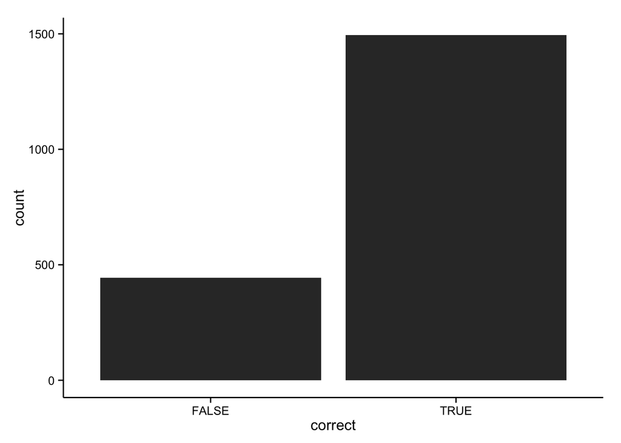

```r
qplot(x=correct, data=df)
```

Histogram rt just to make sure nothing weird is going on

```
## stat_bin: binwidth defaulted to range/30. Use 'binwidth = x' to adjust this.
```

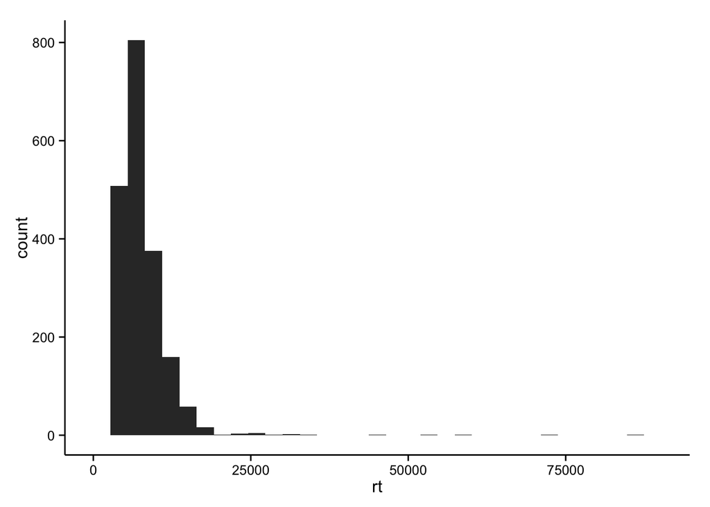

```r
qplot(x=rt, data=df)
```

## Flag and filter bad RTs

```r
df <- df %>%
    filter(id != "NA") %>%
    mutate(include_good_rt = ifelse(log(rt) > mean(log(rt)) + 2 * sd(log(rt)) |
                                        log(rt) < mean(log(rt)) - 2 * sd(log(rt)),
                                    "exclude", "include"))

df %>% group_by(include_good_rt) %>% summarise(n())
```

```
## Source: local data frame [2 x 2]
##
##   include_good_rt  n()
## 1         exclude   44
## 2         include 1780
```

```r
df <- filter(df, include_good_rt == "include")
```

### Main analysis

Plot accuracy for each gate within each sign.

```r
ms <- df %>%
    na.omit() %>%
    group_by(gate_name, gate_num, gate_signer, gate) %>%
    summarise(mean_correct = mean(correct),
              ci_h = ci.high(correct),
              ci_l = ci.low(correct))
```

Now plot

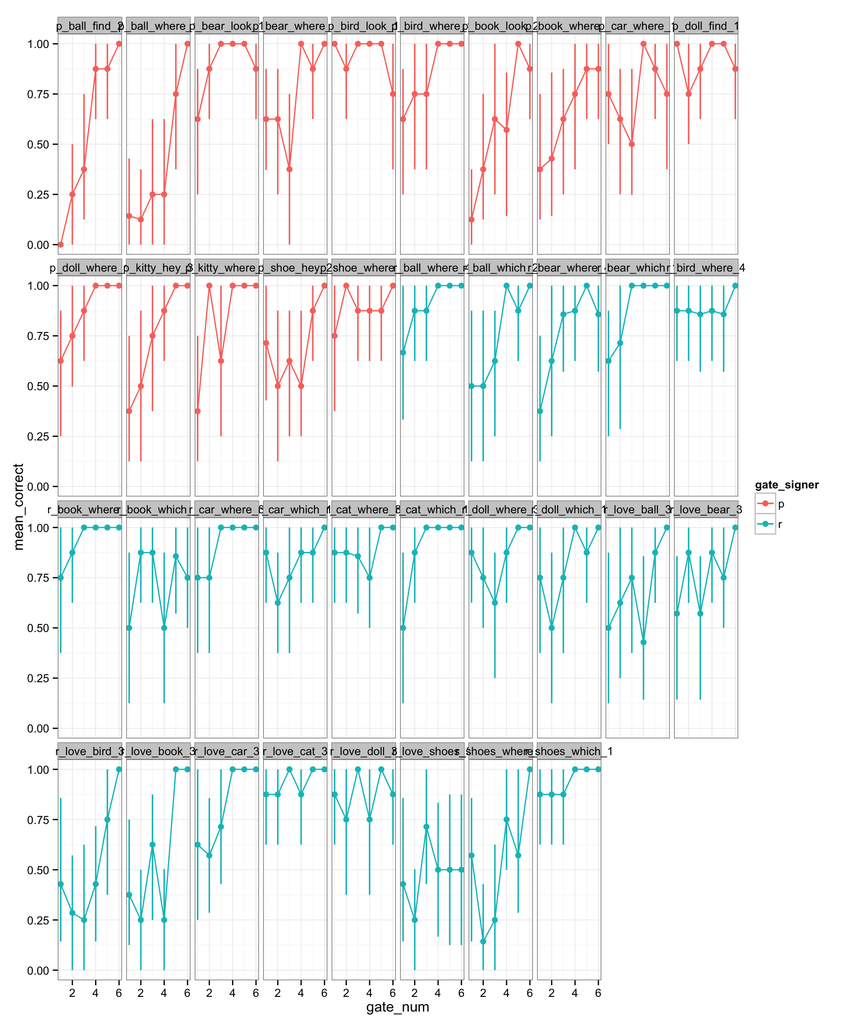

```r
qplot(x=gate_num, y=mean_correct, color = gate_signer, data=ms) +
    facet_wrap( ~ gate_name,ncol=10) +
    geom_line() +
    geom_pointrange(aes(ymin=mean_correct - ci_l,
                        ymax=mean_correct + ci_h),
                    width = .05, size=0.6) +
    theme_bw()
```

### Compute empirical F0

Decisions about gate were made by VM/KM. Decision criteria was as follows: - Earliest gate that achieved accuracy above chance

Note: there were some signs that did not have a clear gate based on the data. In these cases we stick with the experimenter defined F0.

```r
#grab gate names
df_empricial_f0 <- ms %>%
    ungroup() %>%
    select(gate_name) %>%
    unique()

# create vector with gate decisions
gate_decision <- c(4, 5, 3, 4, 1, 4, 5, 5, 4, 1, 4, 5, 2, 6, 6,
                    4, 4, 5, 3, 6, 5, 2, 3, 6, 5, 3, 5, 4, 6, 6, 6,
                    5, 4, 3, 3, 3, 6, 4)
# check length: should be 38
length(gate_decision)
```

```
## [1] 38
```

```r
# bind to gate names
df_empricial_f0 %<>% cbind(gate_decision)
```

Take the gate decisions and add this information to the larger summarized data frame: ms. Then only keep the gates where there is a match between gate_decision and gate_num variables.

```r
ms_gate_decisions <- ms %>%
    left_join(y = df_empricial_f0, by = "gate_name") %>%
    ungroup() %>%
    select(gate_name, gate_num, gate, gate_decision) %>%
    filter(gate_decision == gate_num)
```

Extract the frame information from the gate variable. And convert to ms.

```r
regexp <- "[[:digit:]]"

str_locate(ms_gate_decisions$gate, regexp)[1]
```

```
## [1] 13
```

```r
ms_gate_decisions %<>%
    select(gate, gate_decision) %>%
    mutate(
        f0_sec = as.numeric(str_extract(gate, regexp)),
        f0_frame = as.numeric(str_sub(gate,
                           start = str_length(gate) - 3,
                           end = str_length(gate) - 2)),
        f0_tot_frames = (f0_sec * 30) + f0_frame,
        f0_ms_1 = f0_tot_frames * 33,
        f0_ms_2 = (f0_sec * 1000) + (f0_frame * 33)
    )
```

Save data frame, so we can add the experimenter chosen F0

```r
# write.csv(x = ms_gate_decisions, "sol-empirical-gate-decisions.csv", row.names = F)
```

Read in data frame with experimenter F0 added and compute the difference for each sign and the average difference overall.

```r
df_final <- read.csv("sol-empirical-gate-decisions.csv")
```

Summarise how far off we were. First we compare the difference between empirical and experiment, if we use the following computation to get F0

$frames * 33$

| min_diff_ms | max_diff_ms | min_diff_frames | max_diff_frames | avg_diff_ms | avg_diff_frames |
| --- | --- | --- | --- | --- | --- |
| 7 | 294 | 0 | 9 | 127.29 | 3.89 |

Now we compare the difference if we use the following computation to get F0:

$(seconds * 1000) + (frames * 33)$

| min_diff_ms | max_diff_ms | min_diff_frames | max_diff_frames | avg_diff_ms | avg_diff_frames |
| --- | --- | --- | --- | --- | --- |
| 0 | 274 | 0 | 8 | 107.18 | 3.18 |

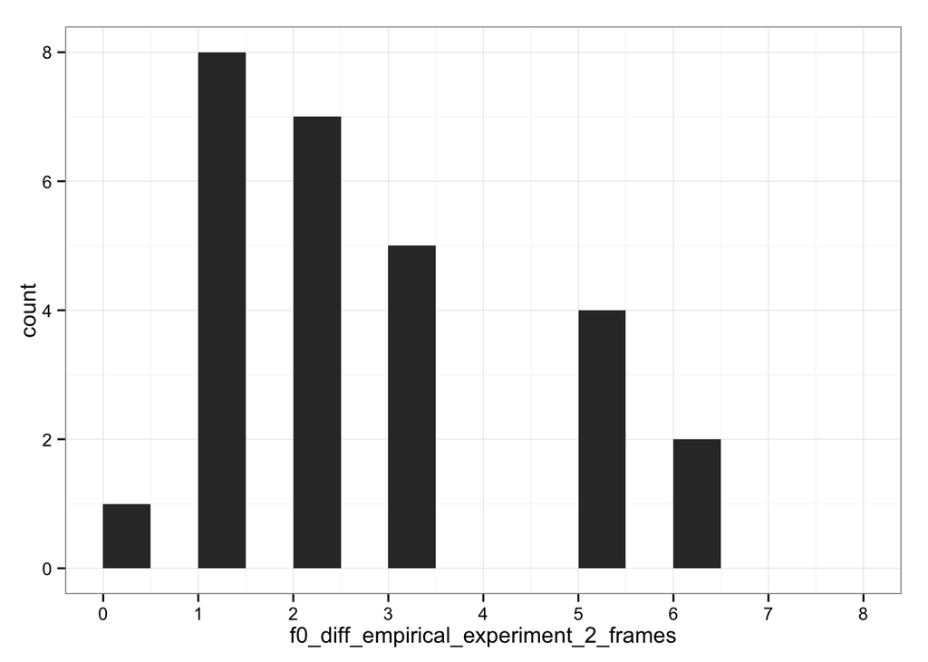

```r
ggplot2::qplot(f0_diff_empirical_experiment_2_frames, data = df_final,
               binwidth = 0.5) +
    ylim(0, 8) +
    scale_x_continuous(limits = c(0, 8), breaks=0:8) +
    theme_bw()
```